# DATA 550 Lab 3 - Communication visualizations

There are two versions of this lab, one in Python and one in R. The R lab will use `ggplot` and the Python lab will use `Altair`.

This is the R version.

Each partner should choose a version to complete, though keep in mind that **you are required to alternate between completing the R labs and the Python labs** to get experience using both languages.

## Acknowledgemnts

This lab was lightly adapted from the one created by Joel Ostblom for the DSCI 531 version of Data Viz I in the 2020/21 Academic year.

## Submission instructions

rubric={mechanics:2}

You receive marks for submitting your lab correctly, please follow these instructions:

- Create a GitHub Repo for your group.
  - Keep this organized, i.e. with a separate clearly marked folder for each assignment.
- [Click here to view a description of the rubrics used to grade the questions](https://github.com/UBC-MDS/public/tree/master/rubric)
- Push your `.ipynb` file to your GitHub repository for this lab.
- Include a clickable link to your GitHub repo for the lab just below this cell
  - It should look something like this https://github.ubc.ca/folder_path/DATA_550_labX_groupY.
- Upload a `.html` version of your assignment to Canvas.
  - Run all cells in your notebook to make sure there are no errors by doing `Kernel -> Restart Kernel and Run All Cells...`
  - Convert your notebook to .html format using `File -> Save and Export Notebook As -> HTML`
  - Submit and double check that your have submitted the correct file to Canvas

## 0. So we meet again...

I am sure you have heard, turns out Bestflix did not make it. Copyright issues they said, can you believe it?? I can't, there must have been more to this story... And the only other person with knowledge of this enterprise was... YOU!

In the spirit of a true comic book criminal, I will scale my revenge for this set back completely out of proportion and attempt world dominion. Don't worry, there will be no blood shed, I operate with class so my plan here is to brainwash people into thinking that I am actually good for them and then reap personal benefits once in power, creative isn't it?

To convince the pleb... I mean honorary citizens of the world to vote for me, I have made several key visualizations showing what an ideal candidate I am. The only way to stop me (hmm why am I telling you this again...) is to debunk these visualizations and show voters the errors of my ways (this is clearly a fictional scenario since we are assuming that each person acts rationally and is convinced by data).

Below is my publicly distributed campaign material covering these four main area:

1. The current dramatic increase in job dissatisfaction
2. My previous record on increasing job wages for all
3. Guns to the people
4. My great approval rating

1. Decide if you think my plot and my claim is misleading or not, why you think so, and how you would improve it in your version of the same figure (unless you think mine is already good). In addition to what we are learning this week, you will need to draw on your knowledge from last week for when certain plots are suitable and which are common pitfalls to avoid.
2. To earn the people's trust, you need to recreate my plot to show that you know what I did. This includes axis labels, legends, colors, titles, figure size, everything as close as possible to the images I have pasted for each question below.
3. Create your own better version of the same figure. Make sure that your choices are motivated in writing in point 1.

# 1. Dramatic decline in job satisfaction

## The data

The `cities-job-satisfaction.csv` dataset contains (fictional) data from different cities around the world. In this data it was measured which proportion of people reported that they were unsatisfied with their work situation this year compared to last year. Each data point is a different city, and the value indicates the proportion of dissatisfied workers.

## My claim

You can clearly see in this plot that people are dramatically more dissatisfied at work this year compared to last year. I have used transparency for the dots to prevent overplotting/oversaturation, so this means that the entire dark area has an even amount of cities throughout. In other words, there are as many cities that increased from ~0% to ~40% dissatisfaction as there are cities that stayed around 0%. That's atrocious!

```r
library(tidyverse)
library(readr)
```

### Question 1.1

rubric={reasoning:2,writing:1}

- Explain which mistakes (if any) I have done in my plot and provide an interpretation of the data that is more correct than mine. Be brief and clear in your answer.
- You might have some ideas just from looking at my plot, but you will likely need to do some investigation yourself to answer this question fully. You can reference your improved plot as needed.

### Question 1.2

rubric={accuracy:2}

#### R

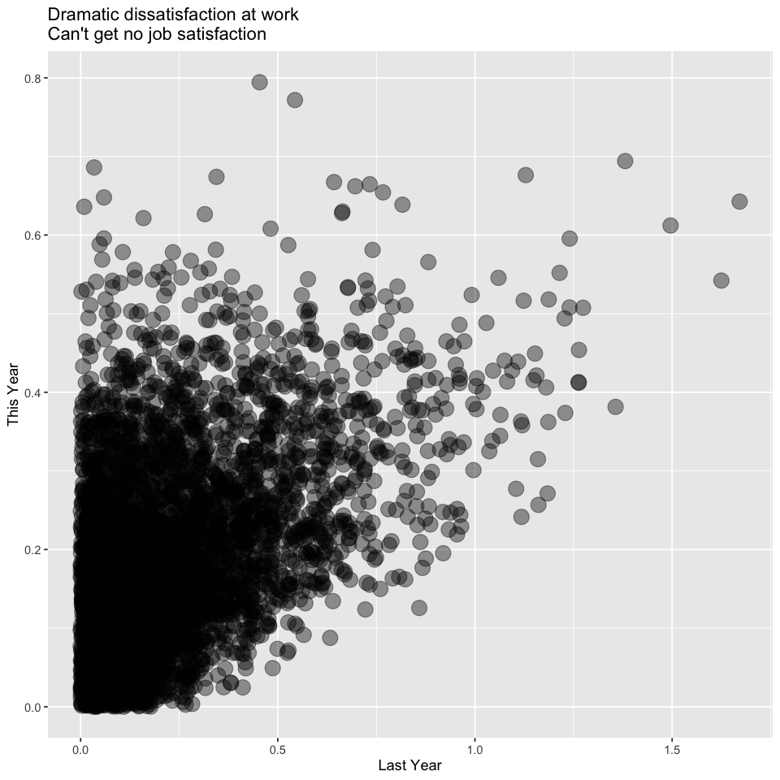

```r
# YOUR ANSWER HERE
cities_df <- read_csv("data/cities-job-satisfaction.csv")
options(repr.plot.width = 8, repr.plot.height = 8)

ggplot(data = cities_df, aes(x = last_year, y=this_year)) +
    geom_point(size=5, alpha=0.4) +
    labs(
        title = "Dramatic dissatisfaction at work\nCan't get no job satisfaction",
        x = "Last Year",
        y = "This Year"
    )
```

### Question 1.3

rubric={viz:2}

#### R

Improve my ggplot plot. Chose the best type of plot to accurately reveal what the data looks like. Design the plot to be an effective plot for communication purposes, this includes proper figure size, axis/figure titles, font sizes, colors, etc.

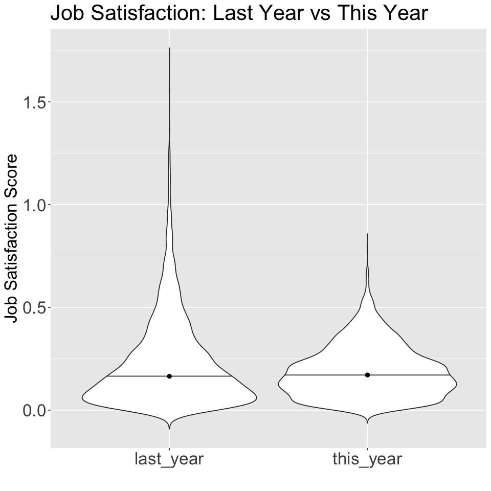

```r
# YOUR ANSWER HERE
df_long <- cities_df %>%
  pivot_longer(
    cols = c(last_year, this_year),
    names_to = "year",
    values_to = "satisfaction"
)

ggplot(df_long, aes(x = year, y = satisfaction)) +
  geom_violin(draw_quantiles = .5, trim = FALSE) +
  labs(
    title = "Job Satisfaction: Last Year vs This Year",
    x = "",
    y = "Job Satisfaction Score"
  ) +
  stat_summary(
    fun = median,
    geom = "point",
    size = 2
  ) +
  theme(
    axis.title = element_text(size = 20),
    axis.text  = element_text(size = 20),
    plot.title = element_text(size = 25)
  )
```

# 2. I will keep raising wages for all

## The data

The `wages.csv` dataset contains (fictional) data from different companies in the city where I have been the mayor for the last few years. Each datapoint represents the average salary at a company. All the major companies in this city were surveyed both before I was elected and after a few years of my governing. However, this is not paired data, some companies are different from "before" and "after", so you do not need to do a paired analysis.

## My claim

As you can see, I have been able to produce a significant increase in the average salary for workers in my city. This high raise almost certainly entails that all (or almost all) workers are receiving a higher payment than what they were before I started to govern. But since I know you are going to ask me for more robust estimates, I have also provided the median increase (which is even more notable) and the number of workers in each group (so that you can see that the samples are balanced).

### Question 2.1

rubric={reasoning:2,writing:1}

- Explain which mistakes (if any) I have done in my plot and provide an interpretation of the data that is more correct than mine. Be brief and clear in your answer.
- You might have some ideas just from looking at my plot, but you will likely need to do some investigation yourself to answer this question fully. You can reference your improved plot as needed.

### Question 2.2

rubric={accuracy:2}

#### R

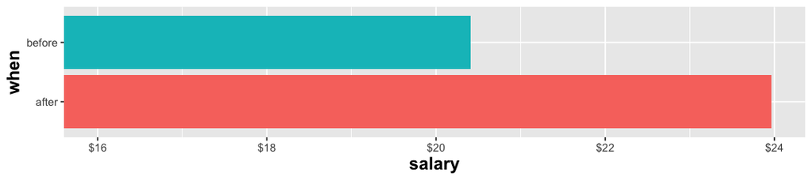

```r
# YOUR ANSWER HERE
library(scales)
options(repr.plot.width = 9, repr.plot.height = 2)

wages_df <- read_csv("data/wages.csv")

mean_wages <- wages_df %>%
   group_by(when) %>%
   summarize(salary = mean(salary))

ggplot(mean_wages, aes(x = salary, y = when, fill = when)) +
   geom_col(width = 0.9) +
   scale_x_continuous(
      breaks = c(16,18,20,22,24),
      labels = dollar) +
      coord_cartesian(xlim = c(16, NA)) +
      theme(
         axis.title = element_text(face = "bold", size = 14),
         legend.position = "none"
         )
```

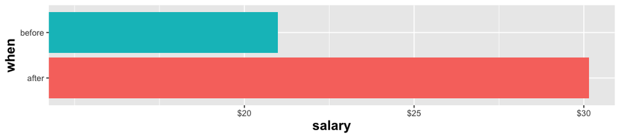

```r
# YOUR ANSWER HERE
median_wages <- wages_df %>%
    group_by(when) %>%
    summarize(salary = median(salary))

ggplot(median_wages, aes(x = salary, y = when, fill = when)) +
    geom_col(width = 0.9) +
    scale_x_continuous(
      breaks = c(20,25,30),
      labels = dollar) +
      coord_cartesian(xlim = c(15, NA)) +
      theme(
         axis.title = element_text(face = "bold", size = 14),
         legend.position = "none"
         )
```

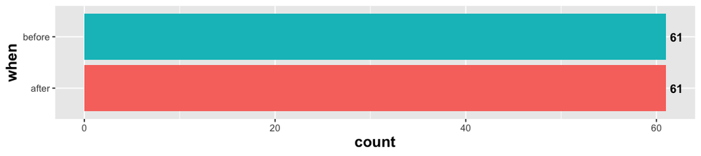

```r
# YOUR ANSWER HERE
count_wages <- wages_df %>%
    group_by(when) %>%
    summarize(count = n())

ggplot(count_wages, aes(x = count, y = when, fill = when)) +
    geom_col(width = 0.9) +
    geom_text(
        aes(label = count),
        hjust = -0.3,
        fontface = "bold"
    ) +
    theme(
        axis.title = element_text(face = "bold", size = 14),
        legend.position = "none"
        )
```

### Question 2.3

rubric={viz:2}

#### R

Improve my ggplot plot. Chose the best type of plot to accurately reveal what the data looks like. Design the plot to be an effective plot for communication purposes, this includes proper figure size, axis/figure titles, font sizes, colors, etc. You can either make a single or several plots, depending on what you think is needed.

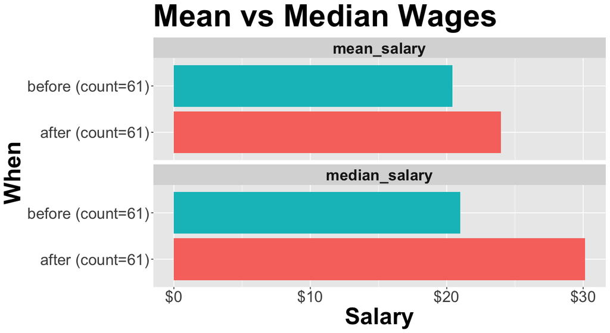

```r
# YOUR ANSWER HERE
options(repr.plot.width = 11, repr.plot.height = 6)

stat_wages <- wages_df %>%
    group_by(when) %>%
    summarize(
    mean_salary = mean(salary),
    median_salary = median(salary),
    count = n()
    ) %>%
    mutate(when = paste0(when, " (count=", count, ")")) %>%
    pivot_longer(
        cols = c(mean_salary, median_salary),
        names_to = "stat",
        values_to = "salary"
    )


ggplot(stat_wages, aes(x = salary, y = when, fill = when)) +
    geom_col() +
    facet_wrap(~stat, ncol = 1) +
    scale_x_continuous(labels = dollar) +
    labs(
        title = "Mean vs Median Wages",
        x = "Salary",
        y = "When"
    ) +
    theme(
        axis.title = element_text(face = "bold", size = 30),
        strip.text = element_text(face = "bold" ,size = 20),
        plot.title = element_text(face = "bold", size = 40),
        axis.text = element_text(size = 20),
        legend.position = "none"
    )
```

# 3. Guns to the people

## The data

The `guns-r-us.csv` dataset contains yearly data for the number of murders by firearms in Florida.

## My claim

As you can see, just after the gun law in Florida was enacted, deaths from firearms plummeted. I don't really think there is much else to discuss here.

### Question 3.1

rubric={reasoning:2,writing:1}

- Explain which mistakes (if any) I have done in my plot and provide an interpretation of the data that is more correct than mine. Be brief and clear in your answer.
- You might have some ideas just from looking at my plot, but you will likely need to do some investigation yourself to answer this question fully. You can reference your improved plot as needed.

The primary issue with the provided plot is the use of a reversed y-axis combined with a filled area chart, which exaggerates changes in firearm murders over time. Because lower values appear higher on the plot, decreases in firearm deaths are visually presented as upward movement into the shaded region, suggesting a substantial improvement. In addition, the annotation “Gun law enacted” is not clearly anchored to the year 2005, and the large shaded region implies a relationship between the enactment of the law and subsequent trends without clearly indicating the timing of the policy change. As a result, the overall trend in firearm murders is difficult to interpret at a glance.

### Question 3.2

rubric={accuracy:2}

#### R

[output not shown]

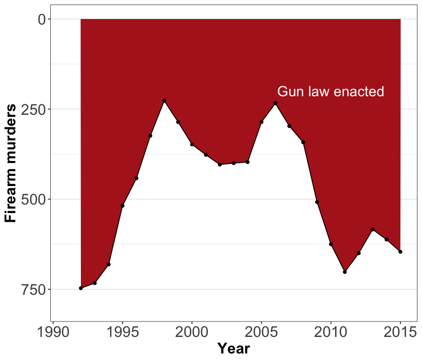

```r
# YOUR ANSWER HERE
options(repr.plot.width = 7, repr.plot.height = 6)

guns_df <- read_csv("data/guns-r-us.csv")

ggplot(guns_df, aes(x = Year, y = `Firearm murders`)) +
  geom_area(fill = "firebrick") +
  geom_line() +
  geom_point() +
  scale_y_reverse(limits = c(800,0), breaks = c(0,250,500,750)) +
  annotate(
    "text",
    x = 2010,
    y = 200,
    label = "Gun law enacted",
    color = "white",
    size = 6
  ) +
  theme_bw() +
  theme(
      axis.title = element_text(face = "bold", size = 18),
      axis.text = element_text(size = 18),
      panel.grid.major.x = element_blank(),
      panel.grid.minor.x = element_blank(),

  )
```

### Question 3.3

rubric={viz:2}

#### R

Improve my ggplot plot. Chose the best type of plot to accurately reveal what the data looks like. Design the plot to be an effective plot for communication purposes, this includes proper figure size, axis/figure titles, font sizes, colors, etc.

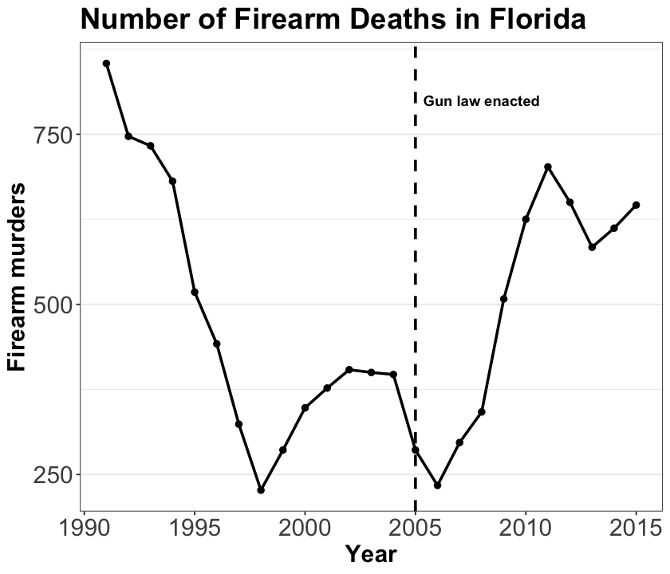

```r
# YOUR ANSWER HERE

ggplot(guns_df, aes(x = Year, y = `Firearm murders`)) +
  geom_line(linewidth = 1) +
  geom_point(size = 2) +
  geom_vline(xintercept = 2005, linetype = "dashed", linewidth = 1) +
  annotate(
    "text",
    x = 2008,
    y = 800,
    label = "Gun law enacted",

    fontface = "bold"
  ) +
  scale_y_continuous(breaks = c(0, 250, 500, 750)) +
  labs(
    title = "Number of Firearm Deaths in Florida",
    x = "Year",
    y = "Firearm murders") +
  theme_bw() +
  theme(
    plot.title = element_text(face = "bold", size = 22),
    axis.title = element_text(face = "bold", size = 18),
    axis.text  = element_text(size = 18),
    panel.grid.major.x = element_blank(),
    panel.grid.minor.x = element_blank()
  )
```

# My approval ratings are astronomical

## The data

The (fictional) `state-comparison.csv` dataset contains a sample of voters from my state and a neighboring state of similar socioeconomic standard. Voters in each state were asked to rate their approval of the state's mayor on a scale from 0 - 10,000.

## My claim

My approval ratings are through the roof! I am clearly doing a better job than my colleague and competitor next doors. And as you can see we sampled enough people to get smooth curves, which means that this difference is both likely to be statistically significant and the magnitude is just too big to ignore. There seems to be a few bores on the lower end of the spectrum, but can't win them all I guess. Do you want a 10k approval rating future?

### Question 4.1

rubric={reasoning:2,writing:1}

- Explain which mistakes (if any) I have done in my plot and provide an interpretation of the data that is more correct than mine. Be brief and clear in your answer.
- You might have some ideas just from looking at my plot, but you will likely need to do some investigation yourself to answer this question fully. You can reference your improved plot as needed.

With only three observations per group, a density plot is not appropriate because it imposes a smoothed distribution that effectively “creates” values between the observed data points. This smoothing exaggerates differences between groups and suggests structure or patterns that may not actually be present in the data.

### Question 4.2

rubric={accuracy:2}

#### R

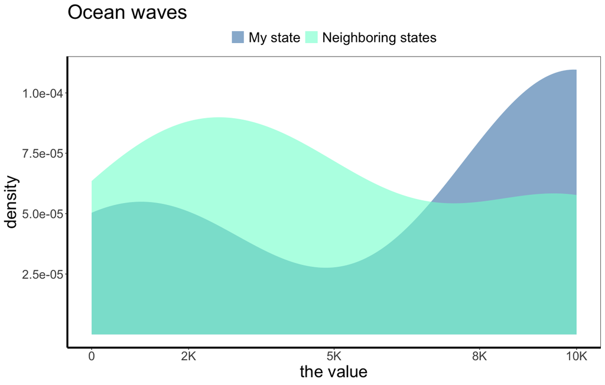

```r
# YOUR ANSWER HERE

options(repr.plot.width = 11, repr.plot.height = 7)

state_df <- read_csv("data/state-comparison.csv")
state_df <- state_df %>%
  mutate(where = factor(where, levels = c("My state", "Neighboring states")))

ggplot(state_df, aes(x = `the value`, fill = where)) +
  geom_density(alpha = 0.6, color = NA) +
  scale_fill_manual(
    values = c(
      "My state" = "steelblue",
      "Neighboring states" = "aquamarine"
    )
  ) +
  labs(
    title = "Ocean waves",
    x = "the value",
    y = "density",
    fill = NULL
  ) +
  scale_x_continuous(
    limits = c(0, 10000),
    breaks = c(0, 2000, 5000, 8000, 10000),
    labels = c("0", "2K", "5K", "8K", "10K")
  ) +
  scale_y_continuous(
    breaks = c(2.5e-5, 5.0e-5, 7.5e-5, 1.0e-4)
  ) +
  theme_bw() +
  theme(
    legend.position = "top",
    legend.text = element_text(size = 18),
    plot.title = element_text(size = 26),
    axis.title.x = element_text(size = 22),
    axis.title.y = element_text(size = 22),
    axis.text = element_text(size = 16),
    axis.line = element_line(linewidth = 1.2),
    panel.grid = element_blank()
  )
```